# arctraining slides – hpc0

## HPC 0

### Introduction to Linux for HPC

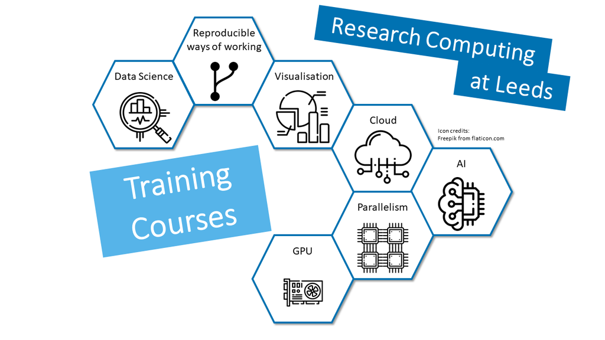

## Research Computing [Team](https://arc.leeds.ac.uk/about/team/) and Service

- Here to support research(ers)
  - Provide training
  - Support users of Grid and Cloud Computing platforms
  - Provide consultancy
    - To develop project proposals
    - To help recruit people with specialist skills
    - Working directly on research projects
- For details please see our [Website](https://arc.leeds.ac.uk/)
- [Contact us via the IT Service Desk](https://bit.ly/arc-help)

## Training Themes

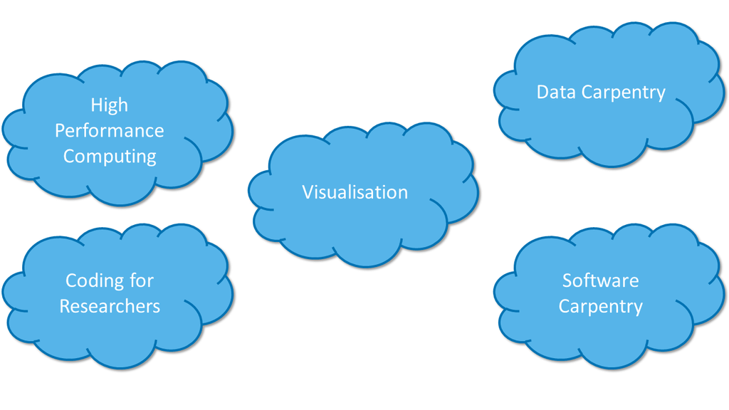

## Aims of this training

- Build your confidence in using command line Linux
- Prepare you for [HPC1: Introduction to High Performance Computing](https://arc.leeds.ac.uk/training/courses/hpc1/)
- Get feedback from you about the training

## Syllabus

- Logging in
- Entering commands
- Finding out about commands
- File system navigation
- Commands to list, create, copy, move and delete files
- Hidden files
- Command history
- Control key combinations
- Editing files
- File permissions
- Commands to explore and filter data
- Wildcards
- Shell scripting basics

## Logging in

- [ARC Documentation on Logging on](https://arcdocs.leeds.ac.uk/getting_started/logon.html)
- How you login depends on your:

### Host Operating System

- OSX/Linux:
  - Use `terminal`
- Windows:
  - Use `MobaXTerm`

### Connection

- On campus (wireless is like ‘off campus’)
- Off campus (connected to the [University VPN](https://it.leeds.ac.uk/it?id=kb_article&sysparm_article=KB0014410) is like ‘on campus’)

## Logging in demos

## Logging in exercise

- Please login

## What is a shell? 1/5

- A shell is a terminal emulator program and scripting language
- The terminal is a window on the screen with a prompt at which commands are entered and where Standard Output (stdout) and Standard Error (stderr) streams get displayed
- During login, set up is finalised by reading files from your `HOME` directory
- When you login you start in your `HOME` directory

## What is a shell? 2/5

- BASH (bash) is a type of shell

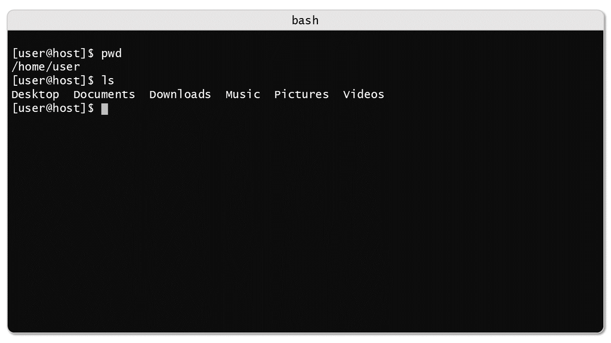

## What is a shell? 3/5

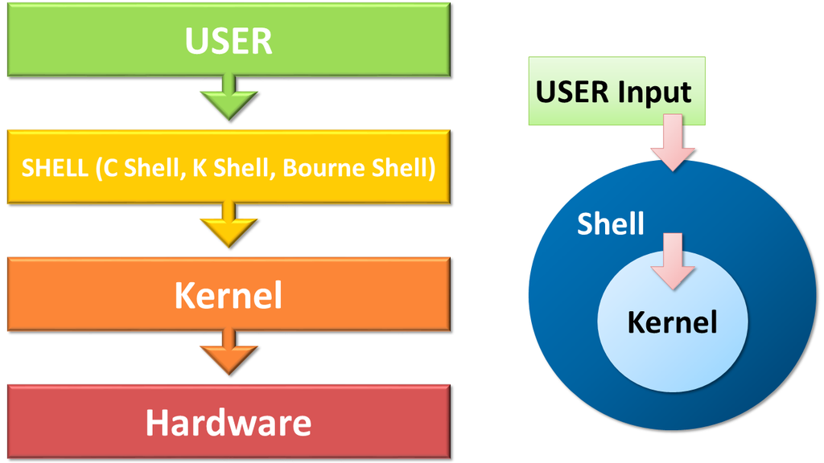

## What is a shell? 4/5

- Shells have `built-in` commands:
  - When called from a shell, these run without invoking (calling) other programs
- Shells call other programs by name, and these are looked for in the user `PATH`
- `PATH` is a variable and ordered list of filesystem directories
- Each user has a `PATH` set upon login
- `PATH` is a variable and can be changed

## What is a shell? 5/5

- On ARC3 and ARC4 additional Linux command utilities are available
- Additional software has also been installed and made available via a module system
- This functionality can differ between ARC3 and ARC4, but is all accessed via the shell

## Filesystem basics

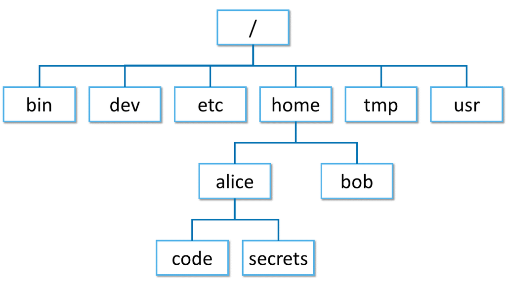

## Forward-slash / and back-slash

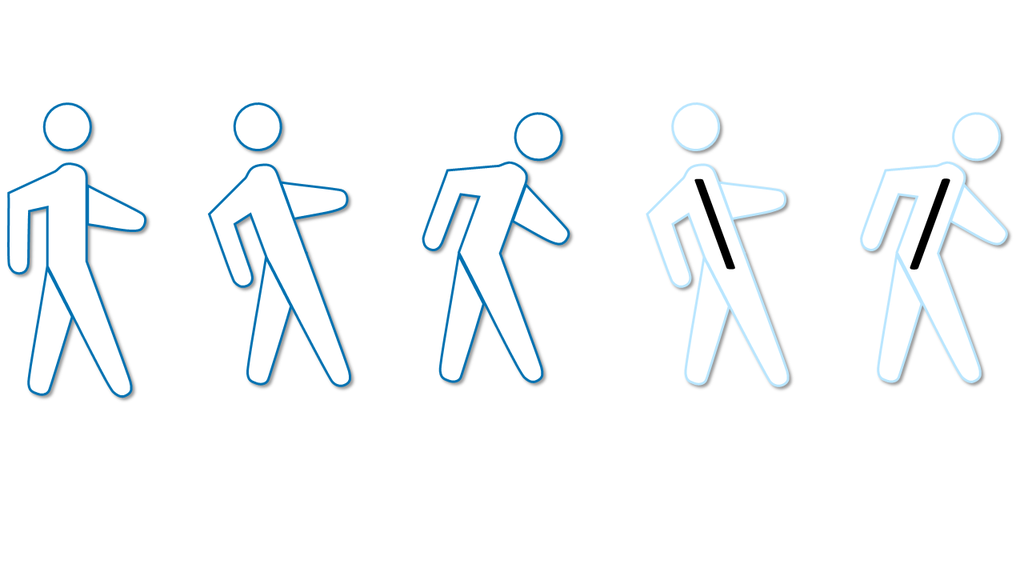

## Absolute path

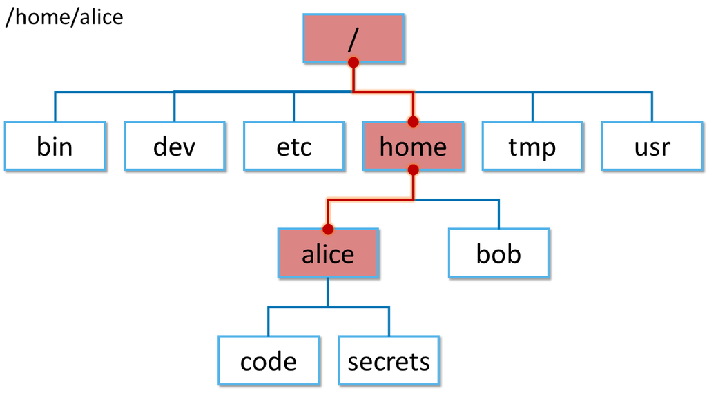